# **Method of Gradient Descent**

# 3.a.2 Implement the Model at lr 0.01.

```python
trajectory, cost, theta_final = mini_gradient_descent(
    initial_guess=np.random.randn(2),
    learning_rate=0.01,
    num_iterations=1000,
    batch_size=10
)
```

# 3.a.3 Plot the first 20 steps of mini-batch gradient descent (lr = 0.01)

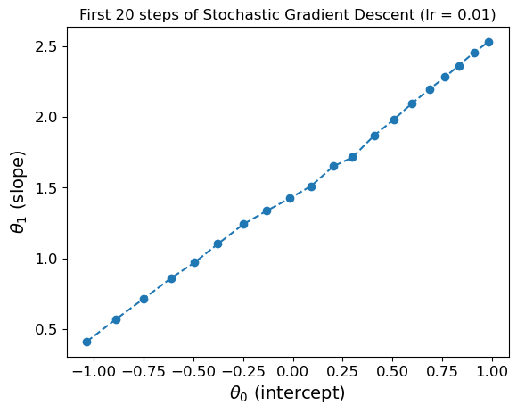

```python
first20 = trajectory[:20, :, 0]  # take first 20 steps

plt.figure()
plt.plot(first20[:, 0], first20[:, 1], marker='o', linestyle='dashed')
plt.xlabel(r"$\theta_0$ (intercept)")
plt.ylabel(r"$\theta_1$ (slope)")
plt.title("First 20 steps of Stochastic Gradient Descent (lr = 0.01)")
plt.show()
```

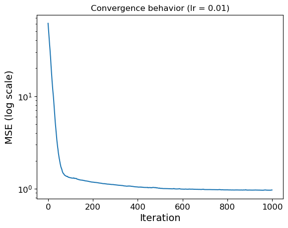

```python
plt.figure()
plt.plot(cost)
plt.yscale("log")
plt.xlabel("Iteration")
plt.ylabel("MSE (log scale)")
plt.title("Convergence behavior (lr = 0.01)")
plt.show()
```

# 3.b.1 Implement the Model at lr 0.1.

```python
trajectory, cost, theta_final = mini_gradient_descent(
    initial_guess=np.random.randn(2),
    learning_rate=0.1,
    num_iterations=1000,
    batch_size=10
)
```

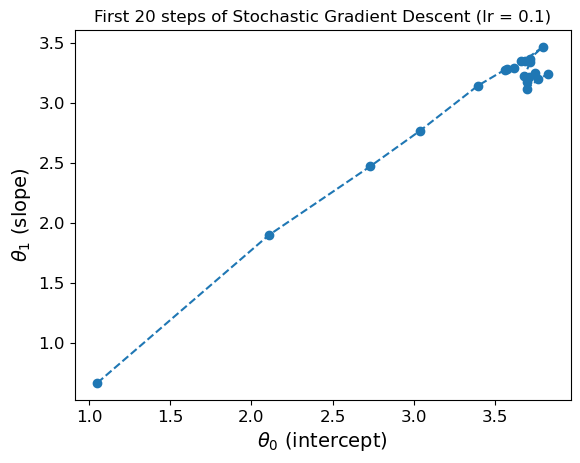

```python
first20 = trajectory[:20, :, 0]  # take first 20 steps

plt.figure()
plt.plot(first20[:, 0], first20[:, 1], marker='o', linestyle='dashed')
plt.xlabel(r"$\theta_0$ (intercept)")
plt.ylabel(r"$\theta_1$ (slope)")
plt.title("First 20 steps of Stochastic Gradient Descent (lr = 0.1)")
plt.show()
```

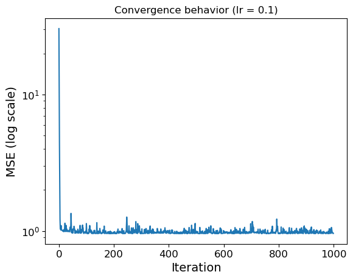

```python
plt.figure()
plt.plot(cost)
plt.yscale("log")
plt.xlabel("Iteration")
plt.ylabel("MSE (log scale)")
plt.title("Convergence behavior (lr = 0.1)")
plt.show()
```

# 4.a Compare stochastic gradient descent, gradient descent, and mini-batch gradient descent in terms of the paths taken by the three gradient descent algorithms in the parameter space during training. What do you observe? Which algorithm shows faster convergence?

Batch Gradient descent appears to have the smoothest and fastest path towards the convergence on an iteration-by-iteration basis, enabling it to use higher learning rates between iterations. However, this is presumably at a cost of computational cost, with each iteration being more expensive. Stochastic Gradient Descent appears to need a lower learning rate to be effective, since its random approach, combined with the small sample size, creates the possibility of overshooting convergence. Its path is less smooth that Batch. Mini-batch approaches convergence at almost the same rate that Batch approaches convergence, but presumably does it "cheaper" on an iteration by iteration basis. Its path is smoother than SGD but less smooth than batch. Overall, mini-batch appears to provide similar perfromance at a presumably lower cost.